# Mean comparison tests

Probabilities and statistics for modelling (CMB STAT1)

Jacques van Helden

2020-03-06

# Contents

We provide here a brief summary (suppsedly reminder) of one ot the most popular applications of statistics: the **mean comparison test**.

This test is used in a wide number of contexts. We will apply it here to two data types.

1. **Artificial data** generated by drawing samples from two normally distributed populations, having either equal ($H_0$) or different ($H_1$) means depending on the cases. The interest of this experiment is that we conrol all the parameters (we know whether there is or not a difference betwen population means).
2. **Trabscriptome data obtained from microarrays**. We will test if a given gene presents a significant difference between two sets of biological samples (e.g. patients suffering from different cancer types).

   **Note:** microarray technologies have been widely replaced by next-generation sequencing (NGS) and RNA-seq has been used to study transcriptome. However, differential analysis with RNA-seq requires more advanced concepts, which will be treated in other courses.

# L’hypothèse à tester

**General principle:**

- We observe a difference between *sample* means, and we would like to know whether it results from sampling fluctuations or from an actual difference between the two populations.
- We define two hypotheses: the *null hypothesis* ($H_0$) states that the two populations means are equal, whereas the *alternative* hypothesis ($H_1$) states that they differ.
- We evaluate the probability for a random sampling to return, under $H_0$, a difference at least as important as the one observed.
- If this probability is very weak, we *reject* the null hypothesis ($RH_0$), else we (temporarily) *accept* it.

# Test bilatéral (*two-tailed test*)

Dans le **test bilatéral** (*two-tailed test*), on désire détecter une éventuelle différence indépendamment de son signe ($\mu_1 > \mu_2$ ou $\mu_2 > \mu_2$).

$$H_0: \mu_1 = \mu_2 \\
H_1: \mu_1 \neq \mu_2$$

# Test unilatéral (*one-tailed test*)

Dans le **test unilatéral** (*one-tailed test*), on s’intéresse spécifiquement à des différences allant dans une direction donnée. L’hypothèse nulle recouvre donc d’une part l’égalité, et d’autre part les différeences de signe opposé à celui qui nous intéresse.

Différences positives (*right-tailed test*):

$$H_0: \mu_1 \le \mu_2 \\
H_1: \mu_1 > \mu_2$$

Différences négatives (*left-tailed test*):

$$H_0: \mu_1 \ge \mu_2 \\
H_1: \mu_1 < \mu_2$$

# Hypothèses de travail

- Il existe différentes méthodes pour tester l’égalité entre deux moyennes.
- Le choix de la méthode dépend de la nature des données.
- Avant de réaliser le test il est crucial de se poser quelques questions afin de choisir la méthode appropriée.
- Il s’agit de **vérifier les hypothèses de travail**, c’est-à-dire des hypothèses *a priori*, sur lesquelles reposera l’approche envisagée. On peut les qualifier de *conditions d’applicabilité* du test.

# Hypothèse de normalité

**Les populations dont les échantillons sont tirés suivent-elles des distributions normales?**

- Si oui on peut réaliser des tests paramétriques (ils reposent sur une hypothèse de normalité). Dans le cas contraire il faut recourir à des tests non-paramétriques.

  **Pourquoi?** Les tables de probabilités de risques des tests paramétriques ont été établies sur base de modèles mathématiques reposant sur l’hypothèse de normalité.
- En cas de non-normalité, **les échantillons sont-ils de grande taille?** Si oui on peut se rabattre sur les méthodes paramétriques

  **Pourquoi?** En vertu du **théorème central limite**, les moyennes d’échantillon tendent vers une normale même si les populations-mères ne sont pas normales.

# Hypothèse d’homoscédasticité (égalité des variances)

Pour les tests paramétriques, **les populations ont-elles (vraisemblablement) la même variance?**

- Si oui on peut appliquer le test de Student.
- Dans le cas contraire, test de Welch.

  **Pourquoi?** La distribution de probabilité de Student a été calculée sur base d’une hypothèse d’**homoscédasticité** (égalité des variances). Le test de Welch effectue une correction en cas d’**hétéroscédasticité** (inégalité des variances), en modifiant le nombre de degrés de liberté en fonction des différences entre variances.

# Logigramme du choix d’un test de comparaison de moyenne

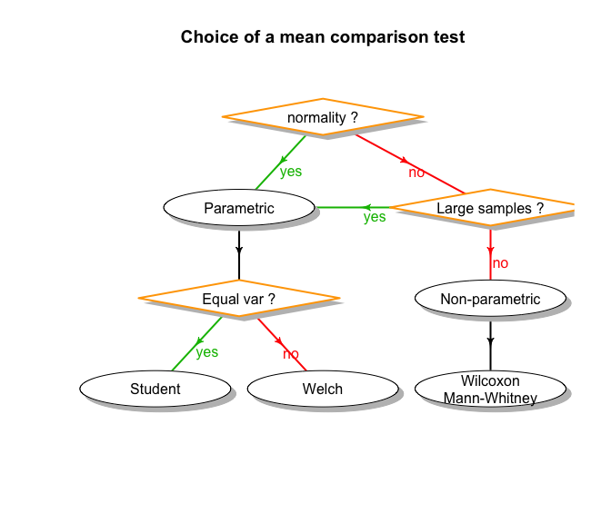

# Test de Student

Hypothèses de travail: **normalité** (ou bien grands échantillons), **homoscédasticité**.

Statistique:

$$t_{S} = \frac{\hat{\delta}}{\hat{\sigma}_\delta} = \frac{\bar{x}_{2} - \bar{x}_{1}}{\sqrt{\frac{n_1 s_{1}^2 + n_2 s_{2}^2}{n_1+n_2-2} \left(\frac{1}{n_1}+ \frac{1}{n_2}\right)}}$$

Estimation du risque de faux-positif (*P-value*): probabilité d’obtenir, *sous hypothèse nulle* une statistique au moins aussi extrême que celle observée. Ce qu’on appellera “extrême” (la ou les queues de distribution à considérer) dépendra du sens du test.

# Décision

- si la P-value est plus faible qu’un seuil fixé ($\alpha$), on rejette l’hypothèse nulle ($RH_0$) et le test est déclaré positif.
- si la P-value est supérieure au seuil fixé ($\alpha$), on accepte l’hypothèse nulle ($AH_0$) et le test est déclaré négatif.

| Sens du test | Critère de décision |
| --- | --- |
| Unilatéral à droite | $RH_0 \quad \text{if} \quad t_S > t_{1-\alpha}^{n_1 + n_2 -2}$ |
| Unilatéral à gauche | $RH_0 \quad \text{if} \quad t_S < t_{alpha}^{n_1 + n_2 -2} = - t_{1-\alpha}^{n_1 + n_2 -2}$ |
| Bilatéral | $RH_0 \quad \text{if} \quad \lvert t_S \rvert > t_{1-\frac{\alpha}{2}}^{n_1 + n_2 -2}$ |

Pour le test bilatéral, on partage le risque de façon symétrique entre les deux queues en associant $\frac{\alpha}{2}$ à chacune.

# Exercice

Un chercheur a analysé, à l’aide de biopuces, le niveau d’expression d’un gène d’intérêt à partir d’échantillons sanguins prélevés chez 50 patients ($n_p=50$) et chez 50 sujets témoins ($n_c=50$). Il obtient

- pour les patients, une moyenne $m_p= 21$
- pour les contrôles, une moyenne $m_c= 10$
- des écarts-types d’échantillons sont identiques pour les 2 groupes $s_p = s_c = s = 15$

Afin de tester si la différence observée entre les moyennes est significative, le chercheur décide d’effectuer un test de Student.

# Exercice